# Space Elasticity Transformation

# 1. Introduction

This script will provide utility functions to transform space elasticity curve These transformations will enable to adjust the curve for store specific parameters

There are **four** types of transformations:  
* **Additive** - Add given list of values to each point in the space elasticity curve  
* **Multiplicative** - Multiply given list of values to each point in the space elasticity curve  
* **Exponential** - Multiply exponential value of given list to each point in the space elasticity curve  
* **Logarithmic** - Multiply logarithmic value of given list to each point in the space elasticity curve

# 2. Demo

Loading base dataset to see how will transformation look like

```r
knitr::opts_chunk$set(root.dir="/home/pushkar/scalene")
library("reshape2")
library("ggplot2")
# getwd()
# knitr::opts_chunk$set(root.dir="/home/pushkar/scalene")
# knitr::opts_knit$set(root.dir="/home/pushkar/scalene")
setwd("/home/pushkar/scalene")
```

```
The working directory was changed to /home/pushkar/scalene inside a notebook chunk. The working directory will be reset when the chunk is finished running. Use the knitr root.dir option in the setup chunk to change the the working directory for notebook chunks.
```

```r
# getwd()
# print(knitr::opts_chunk$get("root.dir"))
source("R/utils/scalene_utilities.R")
source("conf/spaceopt_config.R")
source("R/spaceopt/scoring/space_elasticity_transformation.R")
SPACE_ELASTICITY_PARAMS_DB <- read.csv("data/spaceopt/output/Space_Elasticity_Params_DB.csv",
                                       stringsAsFactors = F)
```

*Ignore the above warning message. I will remove it later*

Lets take a specific product and illustrate the transformation functions Base elasticity curve data looks like this:

```r
i = 50
space_params <- c(SPACE_ELASTICITY_PARAMS_DB$ALPHA[i],
                  SPACE_ELASTICITY_PARAMS_DB$BETA[i],
                  SPACE_ELASTICITY_PARAMS_DB$GAMMA[i],
                  SPACE_ELASTICITY_PARAMS_DB$DELTA[i])
rm(SPACE_ELASTICITY_PARAMS_DB)
curve_data <- data.frame(SPACE=seq(1,25))
curve_data$BASE_KPI <- space_elasticity_values(space_params,curve_data$SPACE)
# curve_data now has the space and corresponding cumulative KPI
head(curve_data)
```

|  | SPACE | BASE_KPI |
| --- | --- | --- |
| 1 | 1 | 33112 |
| 2 | 2 | 34922 |
| 3 | 3 | 36692 |
| 4 | 4 | 38400 |
| 5 | 5 | 40025 |
| 6 | 6 | 41546 |

And the base elasticity curve looks as follows:

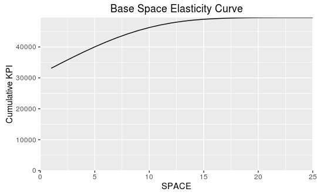

```r
p <- ggplot(data = curve_data) + geom_line(aes(x=SPACE,y=BASE_KPI)) + ggtitle("Base Space Elasticity Curve") + expand_limits(x = 0,y=0) + scale_x_continuous(expand = c(0,0)) + scale_y_continuous(expand = c(0,0)) + ylab("Cumulative KPI")
p
```

And now we will see how the base curve can be transformed.

## 2.1 Additive Transformation

We want to add a value to each of the points of base elasticity curve If the elasticity curve is to be shifted upwards, then we will add a positive value. A negative value will bring down the elasticity curve.

Note that if we add a constant value to all the points of elasticity curve, then the marginal elasticity curve will not change (except for the first unit of space)

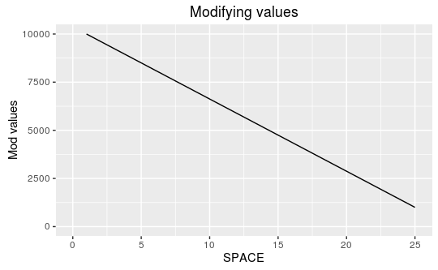

```r
mod_values <- seq(from = 10000, to = 1000, length.out = length(curve_data$BASE_KPI))
p <- ggplot() + geom_line(aes(x=curve_data$SPACE,y=mod_values)) + ggtitle("Modifying values") + expand_limits(x=0,y=0) + ylab("Mod values") + xlab("SPACE")
p
```

We will now see how the curve shifts when we add values to the base curve.

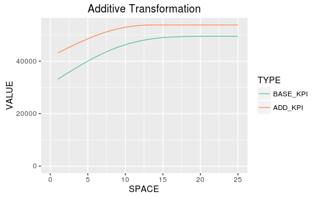

```r
curve_data$ADD_KPI <- elasticity_transformation(curve_values = curve_data$BASE_KPI,
                                                modifying_values = mod_values,
                                                transformType = "ADD")
curve_data.m <- melt(data = curve_data,
                     id.vars = c("SPACE"),
                     value.name = "VALUE",
                     variable.name = "TYPE")
p <- ggplot(curve_data.m, aes(x=SPACE,y=VALUE,colour=TYPE)) + geom_line() + scale_color_brewer(palette = COLOR_PALETTE) + ggtitle("Additive Transformation") + theme_grey() + expand_limits(x=0,y=0)
p
```

**UPDATE: transformation function now returns an increasing function**

We see the error in above graph. We need to ensure that the KPI is an increasing function with Space.

## 2.2 Multiplicative transformation

In Multiplicative Transformation, the curve values for the base curve gets multiplied by the modifying values.

In the example below, we will simulate a situation where the curve should move up by a higher amount in the lower values of space and gradually this increase reduces with higher space.

The modifying values will look as follows:

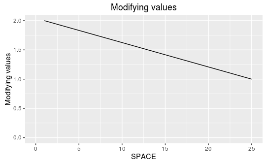

```r
mod_values <- seq(from=2, to=1, length.out = length(curve_data$SPACE))
p <- ggplot() + geom_line(aes(x=curve_data$SPACE,y=mod_values)) + ggtitle("Modifying values") + xlab("SPACE") + ylab("Modifying values") + expand_limits(x=0,y=0) + scale_color_brewer(palette = COLOR_PALETTE) + theme_grey()
p
```

And the transformed space elasticity curves look like this:

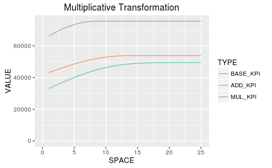

```r
curve_data$MUL_KPI <- elasticity_transformation(curve_values = curve_data$BASE_KPI,
                                                modifying_values = seq(from=2,to=1,length.out = length(curve_data$SPACE)),
                                                transformType = "MUL")
curve_data.m <- melt(data = curve_data,
                     id.vars = c("SPACE"),
                     value.name = "VALUE",
                     variable.name = "TYPE")
p <- ggplot(curve_data.m, aes(x=SPACE,y=VALUE,colour=TYPE)) + geom_line() + scale_color_brewer(palette = COLOR_PALETTE) + ggtitle("Multiplicative Transformation") + theme_grey() + expand_limits(x=0,y=0)
p
```

Note that the curve flattens out as we want to ensure that the elasticity curve is increasing function. Hence the transformation effect may be slightly different from what you feel intuitively.

# 3. Next Steps

Next, we will see how we can use these generic transformations to modify space elasticity curve for store and product specific characteristics

Thanks,  
Pushkar  
Contact me